# ONECITY HEALTH - Data Challenge

## Submitted by - Dhiraj Tripathi

### email: dhiraj.tripathi@rutgers.edu | contact: 551-358-9117

`In this data challenge, we are given a dataset which contains two sheets in xlsx format. There are different columns in these sheets, which describe many properties regarding the fictional patient data. Our goal is to narrow down the search programmatically and explore the data to get some interesting findings. By the end of this python notebook, we should be able to answer most of the questions asked in the problem statement.`

`Let's start our challenge by importing some necessary packages. The code written below will get us the current working directory in which this Ipython notebook is going to be saved.`

```python
import os
os.getcwd()
```

```
'C:\\Users\\dhira'
```

`Pandas and Numpy are the most used packages in python to perform a variety of basic to complex mathematical computation`

```python
import pandas as pd
import numpy as np
```

### Reading the Excel File

```python
completeFile = pd.ExcelFile("F:/GIT/Test_DataCore.xlsx")
```

### Reading the sheets independently to create seperate DataFrames

```python
Sheet1 = pd.read_excel(completeFile, 'Test_DataCore')
Sheet2 = pd.read_excel(completeFile, 'Test_DataCore_VitalStats')
```

### Check Dimensions of the Sheets to get information on number of rows and columns

```python
Sheet1.shape
```

```
(10000, 13)
```

```python
Sheet2.shape
```

```
(98, 2)
```

`The info command in python gives us information on the structure of the data. An important thing to note here is that all the date columns are not of the dtype DateTime. We need to convert these columns in order to perform data operations without any errors`

```python
Sheet1.info()
```

```
<class 'pandas.core.frame.DataFrame'>
RangeIndex: 10000 entries, 0 to 9999
Data columns (total 13 columns):
ID                            10000 non-null int64
VISIT_ID                      10000 non-null int64
ADMISSION_DATE_TIME           10000 non-null object
DISCHARGE_DATE_TIME           9792 non-null object
CLINIC_CODE                   9567 non-null float64
BIRTHDATE                     10000 non-null object
SEX                           10000 non-null object
RACE                          10000 non-null object
DATE_OF_DEATH                 332 non-null object
VISIT_ACTIVATION_DATE_TIME    10000 non-null object
DISCHARGE_TYPE                9745 non-null object
FACILITY                      10000 non-null object
VISIT_STATUS                  10000 non-null object
dtypes: float64(1), int64(2), object(10)
memory usage: 1015.7+ KB
```

```python
Sheet2.info()
```

```
<class 'pandas.core.frame.DataFrame'>
RangeIndex: 98 entries, 0 to 97
Data columns (total 2 columns):
ID               98 non-null int64
DATE_OF_DEATH    98 non-null object
dtypes: int64(1), object(1)
memory usage: 1.6+ KB
```

### Data Cleaning

`The biggest challenge in this dataset is that the data was not at all consistent especially the date columns. Some of the date columns even contain microseconds and hence converting them into a consistent format was necessary.`

```python
Sheet1['ADMISSION_DATE_TIME'] = pd.to_datetime(Sheet1['ADMISSION_DATE_TIME'],format='%d%b%y:%H:%M:%S').dt.normalize()
Sheet1['DISCHARGE_DATE_TIME'] = pd.to_datetime(Sheet1['DISCHARGE_DATE_TIME'],format='%d%b%y:%H:%M:%S').dt.normalize()
Sheet1['BIRTHDATE'] = pd.to_datetime(Sheet1['BIRTHDATE'],format='%d%b%y:%H:%M:%S').dt.normalize()
Sheet1['DATE_OF_DEATH'] = pd.to_datetime(Sheet1['DATE_OF_DEATH'],format = '%Y-%m-%d %H:%M:%S.%f').dt.normalize()
Sheet1['VISIT_ACTIVATION_DATE_TIME'] = pd.to_datetime(Sheet1['VISIT_ACTIVATION_DATE_TIME'],format='%d%b%y:%H:%M:%S').dt.normalize()
```

`Check the information of the sheets again and you will notice that the dtype of the date columns are now changed to DateTime64[ns]. Here [ns] represents nano-seconds. So, even if the date column has micro-seconds, we should be able to tackle that.`

```python
Sheet1.info()
```

```
<class 'pandas.core.frame.DataFrame'>
RangeIndex: 10000 entries, 0 to 9999
Data columns (total 13 columns):
ID                            10000 non-null int64
VISIT_ID                      10000 non-null int64
ADMISSION_DATE_TIME           10000 non-null datetime64[ns]
DISCHARGE_DATE_TIME           9792 non-null datetime64[ns]
CLINIC_CODE                   9567 non-null float64
BIRTHDATE                     10000 non-null datetime64[ns]
SEX                           10000 non-null object
RACE                          10000 non-null object
DATE_OF_DEATH                 332 non-null datetime64[ns]
VISIT_ACTIVATION_DATE_TIME    10000 non-null datetime64[ns]
DISCHARGE_TYPE                9745 non-null object
FACILITY                      10000 non-null object
VISIT_STATUS                  10000 non-null object
dtypes: datetime64[ns](5), float64(1), int64(2), object(5)
memory usage: 1015.7+ KB
```

`An important thing to notice is the clean format of all the Date columns in the sheets.`

```python
Sheet1.head()
```

|  | ID | VISIT_ID | ADMISSION_DATE_TIME | DISCHARGE_DATE_TIME | CLINIC_CODE | BIRTHDATE | SEX | RACE | DATE_OF_DEATH | VISIT_ACTIVATION_DATE_TIME | DISCHARGE_TYPE | FACILITY | VISIT_STATUS |
| --- | --- | --- | --- | --- | --- | --- | --- | --- | --- | --- | --- | --- | --- |
| 0 | 22300992 | 1152389109 | 2014-11-25 | 2014-11-25 | 0.0 | 2051-05-24 | Male | Black or African American | NaT | 2014-11-25 | discharge (routine) | H + H Facility | discharged |
| 1 | 22300992 | 1155584209 | 2014-12-16 | 2014-12-18 | NaN | 2051-05-24 | Male | Black or African American | NaT | 2014-12-16 | discharge (routine) | H + H Facility | discharged |
| 2 | 22300992 | 1156688486 | 2014-12-22 | 2014-12-22 | 60.0 | 2051-05-24 | Male | Black or African American | NaT | 2014-12-22 | routine | H + H Facility | closed discharged |
| 3 | 22300992 | 1156878696 | 2014-12-23 | 2014-12-24 | 860.0 | 2051-05-24 | Male | Black or African American | NaT | 2014-12-23 | routine | H + H Facility | closed discharged |
| 4 | 22300992 | 1157298654 | 2014-12-28 | 2014-12-28 | 884.0 | 2051-05-24 | Male | Black or African American | NaT | 2014-12-28 | discharge (routine) | H + H Facility | closed discharged |

```python
Sheet2['DATE_OF_DEATH'] = pd.to_datetime(Sheet2['DATE_OF_DEATH']).dt.normalize()
```

```python
Sheet2.head()
```

|  | ID | DATE_OF_DEATH |
| --- | --- | --- |
| 0 | 819392 | 2015-07-10 |
| 1 | 15150240 | 2015-11-15 |
| 2 | 28438144 | 2015-07-02 |
| 3 | 28653184 | 2015-10-30 |
| 4 | 30041536 | 2015-02-25 |

### Data Munging

`We need to merge the dataframes and combine it into one. Both the dataframes contain redundant information on patient IDs and the date of death information for them, along with some extra variables.`

```python
combineData = Sheet1.append(Sheet2,sort=False)
combineData.shape
```

```
(10098, 13)
```

```python
combineData.head()
```

|  | ID | VISIT_ID | ADMISSION_DATE_TIME | DISCHARGE_DATE_TIME | CLINIC_CODE | BIRTHDATE | SEX | RACE | DATE_OF_DEATH | VISIT_ACTIVATION_DATE_TIME | DISCHARGE_TYPE | FACILITY | VISIT_STATUS |
| --- | --- | --- | --- | --- | --- | --- | --- | --- | --- | --- | --- | --- | --- |
| 0 | 22300992 | 1.152389e+09 | 2014-11-25 | 2014-11-25 | 0.0 | 2051-05-24 | Male | Black or African American | NaT | 2014-11-25 | discharge (routine) | H + H Facility | discharged |
| 1 | 22300992 | 1.155584e+09 | 2014-12-16 | 2014-12-18 | NaN | 2051-05-24 | Male | Black or African American | NaT | 2014-12-16 | discharge (routine) | H + H Facility | discharged |
| 2 | 22300992 | 1.156688e+09 | 2014-12-22 | 2014-12-22 | 60.0 | 2051-05-24 | Male | Black or African American | NaT | 2014-12-22 | routine | H + H Facility | closed discharged |
| 3 | 22300992 | 1.156879e+09 | 2014-12-23 | 2014-12-24 | 860.0 | 2051-05-24 | Male | Black or African American | NaT | 2014-12-23 | routine | H + H Facility | closed discharged |
| 4 | 22300992 | 1.157299e+09 | 2014-12-28 | 2014-12-28 | 884.0 | 2051-05-24 | Male | Black or African American | NaT | 2014-12-28 | discharge (routine) | H + H Facility | closed discharged |

### Total Number of Unique Patients:

`AS asked in the problem statement, we used the 'nunique' function to find out how many unique records exist in the patient ID columns. This will tell us the total number of patients in the dataset.`

```python
combineData['ID'].nunique()
```

```
169
```

```python
demographicData = combineData.drop_duplicates(subset='ID', inplace=False)
demographicData.head()
```

|  | ID | VISIT_ID | ADMISSION_DATE_TIME | DISCHARGE_DATE_TIME | CLINIC_CODE | BIRTHDATE | SEX | RACE | DATE_OF_DEATH | VISIT_ACTIVATION_DATE_TIME | DISCHARGE_TYPE | FACILITY | VISIT_STATUS |
| --- | --- | --- | --- | --- | --- | --- | --- | --- | --- | --- | --- | --- | --- |
| 0 | 22300992 | 1.152389e+09 | 2014-11-25 | 2014-11-25 | 0.0 | 2051-05-24 | Male | Black or African American | NaT | 2014-11-25 | discharge (routine) | H + H Facility | discharged |
| 33 | 23665824 | 4.335787e+08 | 2003-03-10 | 2003-03-13 | 0.0 | 2052-04-14 | Female | Hispanic | NaT | 2003-03-09 | routine | H + H Facility | closed discharged |
| 93 | 24810016 | 3.871856e+08 | 2002-04-09 | 2002-04-10 | 230.0 | 2057-12-04 | Female | Black or African American | NaT | 2002-04-09 | Routine | H + H Facility | discharged |
| 273 | 26523392 | 3.305710e+08 | 2001-03-26 | 2001-03-26 | 269.0 | 2067-12-31 | Male | Hispanic | NaT | 2001-03-26 | routine | H + H Facility | closed discharged |
| 299 | 27421632 | 6.117502e+08 | 2006-07-15 | 2006-07-16 | 4.0 | 2062-04-05 | Female | Black or African American | NaT | 2006-07-15 | discharge (routine) | H + H Facility | closed discharged |

```python
demographicData.shape
```

```
(169, 13)
```

```python
demographicData['ID'].value_counts()
```

```
7453600     1
21542752    1
38659264    1
69495776    1
36042944    1
3435936     1
44648352    1
35764288    1
28438144    1
20292384    1
26154688    1
50986208    1
42370720    1
34861120    1
52633504    1
```

[output cut: 155 more lines]

`After combinining the data, we need to drop the duplicate records from the combined dataframe and form a new dataframe , which will be used for visualiing and interpreting the demographic data.`

```python
demographicData.head()
```

|  | ID | VISIT_ID | ADMISSION_DATE_TIME | DISCHARGE_DATE_TIME | CLINIC_CODE | BIRTHDATE | SEX | RACE | DATE_OF_DEATH | VISIT_ACTIVATION_DATE_TIME | DISCHARGE_TYPE | FACILITY | VISIT_STATUS |
| --- | --- | --- | --- | --- | --- | --- | --- | --- | --- | --- | --- | --- | --- |
| 0 | 22300992 | 1.152389e+09 | 2014-11-25 | 2014-11-25 | 0.0 | 2051-05-24 | Male | Black or African American | NaT | 2014-11-25 | discharge (routine) | H + H Facility | discharged |
| 33 | 23665824 | 4.335787e+08 | 2003-03-10 | 2003-03-13 | 0.0 | 2052-04-14 | Female | Hispanic | NaT | 2003-03-09 | routine | H + H Facility | closed discharged |
| 93 | 24810016 | 3.871856e+08 | 2002-04-09 | 2002-04-10 | 230.0 | 2057-12-04 | Female | Black or African American | NaT | 2002-04-09 | Routine | H + H Facility | discharged |
| 273 | 26523392 | 3.305710e+08 | 2001-03-26 | 2001-03-26 | 269.0 | 2067-12-31 | Male | Hispanic | NaT | 2001-03-26 | routine | H + H Facility | closed discharged |
| 299 | 27421632 | 6.117502e+08 | 2006-07-15 | 2006-07-16 | 4.0 | 2062-04-05 | Female | Black or African American | NaT | 2006-07-15 | discharge (routine) | H + H Facility | closed discharged |

### Data Visualization:

`We have imported an essential visualization package for python. A noteworthy point is that we are considering two factos : 1)RACE 2)SEX , in the same visualization. A single graph can give us a lot of information on the demographics.`

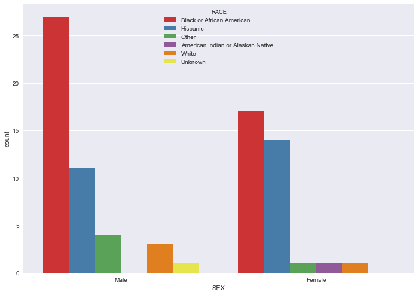

```python
import seaborn as sns
sns.set(style = 'darkgrid')
sns.set(rc={'figure.figsize':(11.7,8.27)})
sns.countplot(x='SEX', hue = 'RACE',data=demographicData , palette = "Set1" )
```

```python
combineData.isna().sum()
```

```
ID                               0
VISIT_ID                        98
ADMISSION_DATE_TIME             98
DISCHARGE_DATE_TIME            306
CLINIC_CODE                    531
BIRTHDATE                       98
SEX                             98
RACE                            98
DATE_OF_DEATH                 9668
VISIT_ACTIVATION_DATE_TIME      98
DISCHARGE_TYPE                 353
FACILITY                        98
VISIT_STATUS                    98
dtype: int64
```

```python
deadpatientData = combineData.dropna(subset=['DATE_OF_DEATH'])
deadpatientData.shape
```

```
(430, 13)
```

```python
deadpatientData.isna().sum()
```

```
ID                              0
VISIT_ID                       98
ADMISSION_DATE_TIME            98
DISCHARGE_DATE_TIME           105
CLINIC_CODE                   102
BIRTHDATE                      98
SEX                            98
RACE                           98
DATE_OF_DEATH                   0
VISIT_ACTIVATION_DATE_TIME     98
DISCHARGE_TYPE                105
FACILITY                       98
VISIT_STATUS                   98
dtype: int64
```

```python
pd.set_option('display.max_rows', 2000)
deadpatientData
```

|  | ID | VISIT_ID | ADMISSION_DATE_TIME | DISCHARGE_DATE_TIME | CLINIC_CODE | BIRTHDATE | SEX | RACE | DATE_OF_DEATH | VISIT_ACTIVATION_DATE_TIME | DISCHARGE_TYPE | FACILITY | VISIT_STATUS |
| --- | --- | --- | --- | --- | --- | --- | --- | --- | --- | --- | --- | --- | --- |
| 393 | 28438144 | 2.883912e+08 | 2000-06-13 | 2000-07-01 | 656.0 | 1988-03-21 | Female | Black or African American | 2015-07-02 | 2000-06-13 | routine | H + H Facility | discharged |
| 394 | 28438144 | 3.171398e+08 | 2000-12-22 | 2000-12-29 | 656.0 | 1988-03-21 | Female | Black or African American | 2015-07-02 | 2000-12-22 | routine | H + H Facility | discharged |
| 395 | 28438144 | 4.079258e+08 | 2002-09-03 | 2002-09-03 | 7.0 | 1988-03-21 | Female | Black or African American | 2015-07-02 | 2002-09-03 | routine | H + H Facility | discharged |
| 396 | 28438144 | 4.329317e+08 | 2003-03-04 | 2003-03-07 | 7.0 | 1988-03-21 | Female | Black or African American | 2015-07-02 | 2003-03-04 | routine | H + H Facility | discharged |
| 397 | 28438144 | 4.639150e+08 | 2003-10-09 | 2003-10-14 | 7.0 | 1988-03-21 | Female | Black or African American | 2015-07-02 | 2003-10-09 | routine | H + H Facility | closed discharged |
| 398 | 28438144 | 4.663172e+08 | 2003-10-20 | 2003-10-27 | 590.0 | 1988-03-21 | Female | Black or African American | 2015-07-02 | 2003-10-20 | routine | H + H Facility | closed discharged |
| 399 | 28438144 | 4.664979e+08 | 2003-10-28 | 2003-10-28 | 7.0 | 1988-03-21 | Female | Black or African American | 2015-07-02 | 2003-10-28 | routine | H + H Facility | closed discharged |
| 400 | 28438144 | 4.671861e+08 | 2003-11-01 | 2003-11-07 | 656.0 | 1988-03-21 | Female | Black or African American | 2015-07-02 | 2003-11-01 | discharge (routine) | H + H Facility | closed discharged |
| 401 | 28438144 | 4.711685e+08 | 2003-12-02 | 2003-12-03 | 7.0 | 1988-03-21 | Female | Black or African American | 2015-07-02 | 2003-12-02 | routine | H + H Facility | closed discharged |
| 402 | 28438144 | 4.742204e+08 | 2003-12-12 | 2003-12-23 | 590.0 | 1988-03-21 | Female | Black or African American | 2015-07-02 | 2003-12-12 | routine | H + H Facility | closed discharged |
| 403 | 28438144 | 4.759061e+08 | 2003-12-17 | 2004-01-07 | 590.0 | 1988-03-21 | Female | Black or African American | 2015-07-02 | 2003-12-17 | routine | H + H Facility | closed discharged |
| 404 | 28438144 | 4.811387e+08 | 2004-02-13 | NaT | 530.0 | 1988-03-21 | Female | Black or African American | 2015-07-02 | 2004-02-13 | NaN | H + H Facility | closed cancelled |
| 405 | 28438144 | 4.821440e+08 | 2004-02-12 | 2004-02-20 | 590.0 | 1988-03-21 | Female | Black or African American | 2015-07-02 | 2004-02-12 | routine | H + H Facility | closed discharged |
| 406 | 28438144 | 4.831588e+08 | 2004-02-25 | 2004-02-26 | 590.0 | 1988-03-21 | Female | Black or African American | 2015-07-02 | 2004-02-25 | routine | H + H Facility | closed discharged |
| 407 | 28438144 | 4.920241e+08 | 2004-04-26 | 2004-05-01 | 530.0 | 1988-03-21 | Female | Black or African American | 2015-07-02 | 2004-04-26 | routine | H + H Facility | discharged |
| 408 | 28438144 | 4.937546e+08 | 2004-05-05 | 2004-05-07 | 590.0 | 1988-03-21 | Female | Black or African American | 2015-07-02 | 2004-05-05 | routine | H + H Facility | closed discharged |
| 409 | 28438144 | 4.944903e+08 | 2004-05-12 | 2004-05-13 | 7.0 | 1988-03-21 | Female | Black or African American | 2015-07-02 | 2004-05-12 | routine | H + H Facility | closed discharged |
| 410 | 28438144 | 5.029076e+08 | 2004-07-10 | 2004-07-10 | 656.0 | 1988-03-21 | Female | Black or African American | 2015-07-02 | 2004-07-10 | discharge (routine) | H + H Facility | closed discharged |
| 411 | 28438144 | 5.128228e+08 | 2004-09-21 | 2004-09-22 | 7.0 | 1988-03-21 | Female | Black or African American | 2015-07-02 | 2004-09-21 | routine | H + H Facility | closed discharged |
| 412 | 28438144 | 5.229402e+08 | 2004-12-01 | 2004-12-01 | 7.0 | 1988-03-21 | Female | Black or African American | 2015-07-02 | 2004-12-01 | routine | H + H Facility | closed discharged |
| 413 | 28438144 | 5.240009e+08 | 2004-12-08 | 2004-12-08 | 7.0 | 1988-03-21 | Female | Black or African American | 2015-07-02 | 2004-12-08 | routine | H + H Facility | discharged |
| 414 | 28438144 | 5.416398e+08 | 2005-04-07 | 2005-04-07 | 560.0 | 1988-03-21 | Female | Black or African American | 2015-07-02 | 2005-04-07 | routine | H + H Facility | closed discharged |
| 415 | 28438144 | 5.452698e+08 | 2005-04-30 | 2005-05-02 | 656.0 | 1988-03-21 | Female | Black or African American | 2015-07-02 | 2005-04-30 | discharge (routine) | H + H Facility | closed discharged |
| 416 | 28438144 | 5.454965e+08 | 2005-05-02 | 2005-05-03 | 656.0 | 1988-03-21 | Female | Black or African American | 2015-07-02 | 2005-05-02 | discharge (routine) | H + H Facility | closed discharged |
| 417 | 28438144 | 5.716761e+08 | 2005-10-25 | 2005-10-25 | 7.0 | 1988-03-21 | Female | Black or African American | 2015-07-02 | 2005-10-25 | routine | H + H Facility | discharged |
| 418 | 28438144 | 5.718850e+08 | 2005-10-26 | 2005-10-26 | 7.0 | 1988-03-21 | Female | Black or African American | 2015-07-02 | 2005-10-26 | routine | H + H Facility | closed discharged |
| 419 | 28438144 | 5.733240e+08 | 2005-11-02 | 2005-11-04 | 354.0 | 1988-03-21 | Female | Black or African American | 2015-07-02 | 2005-11-02 | routine | H + H Facility | closed discharged |
| 420 | 28438144 | 5.846120e+08 | 2006-01-26 | 2006-01-26 | 7.0 | 1988-03-21 | Female | Black or African American | 2015-07-02 | 2006-01-26 | routine | H + H Facility | closed discharged |
| 421 | 28438144 | 5.953619e+08 | 2006-04-03 | 2006-04-04 | 530.0 | 1988-03-21 | Female | Black or African American | 2015-07-02 | 2006-04-03 | routine | H + H Facility | discharged |
| 422 | 28438144 | 6.294809e+08 | 2006-11-06 | 2006-11-08 | 530.0 | 1988-03-21 | Female | Black or African American | 2015-07-02 | 2006-11-06 | routine | H + H Facility | discharged |

[output cut: 400 more lines]

### Number of Patients who died:

`We transformed the data to find out for how many patients the value of "Date_Of_Death" column is not null and then , we calculate the unique records to check how many patients have died.`

```python
deadpatientData['ID'].nunique()
```

```
98
```

```python
deadpatientData['ID'].value_counts()
```

```
30041536    206
28438144     95
819392       18
30172352     17
76682144      1
82681088      1
20292384      1
12356512      1
13554016      1
71929984      1
55682368      1
52633504      1
15150240      1
13752928      1
72760128      1
```

[output cut: 84 more lines]

```python
deadpatientData.isna().sum()
```

```
ID                              0
VISIT_ID                       98
ADMISSION_DATE_TIME            98
DISCHARGE_DATE_TIME           105
CLINIC_CODE                   102
BIRTHDATE                      98
SEX                            98
RACE                           98
DATE_OF_DEATH                   0
VISIT_ACTIVATION_DATE_TIME     98
DISCHARGE_TYPE                105
FACILITY                       98
VISIT_STATUS                   98
dtype: int64
```

### Subsetting the Data:

`After finding how many patients have died, the next step towards the problem statement is to calculate the number of days between the last visit of the patient and the date of the death.`

```python
df = deadpatientData[['ID','ADMISSION_DATE_TIME','DATE_OF_DEATH']]
df.index = range(len(df.index))
df.head()
```

|  | ID | ADMISSION_DATE_TIME | DATE_OF_DEATH |
| --- | --- | --- | --- |
| 0 | 28438144 | 2000-06-13 | 2015-07-02 |
| 1 | 28438144 | 2000-12-22 | 2015-07-02 |
| 2 | 28438144 | 2002-09-03 | 2015-07-02 |
| 3 | 28438144 | 2003-03-04 | 2015-07-02 |
| 4 | 28438144 | 2003-10-09 | 2015-07-02 |

`We can easily notice that some of the patient IDs contribute the most to this data. These are reduntant values and we need to get rid of them.`

```python
df['ID'].value_counts()
```

```
30041536    206
28438144     95
819392       18
30172352     17
76682144      1
82681088      1
20292384      1
12356512      1
13554016      1
71929984      1
55682368      1
52633504      1
15150240      1
13752928      1
72760128      1
```

[output cut: 84 more lines]

`Check the duplicate values in the ID column. We will only consider the last visit of the patient because that's what the problem statement requires.`

```python
print(df)
```

```
           ID ADMISSION_DATE_TIME DATE_OF_DEATH
0    28438144          2000-06-13    2015-07-02
1    28438144          2000-12-22    2015-07-02
2    28438144          2002-09-03    2015-07-02
3    28438144          2003-03-04    2015-07-02
4    28438144          2003-10-09    2015-07-02
5    28438144          2003-10-20    2015-07-02
6    28438144          2003-10-28    2015-07-02
7    28438144          2003-11-01    2015-07-02
8    28438144          2003-12-02    2015-07-02
9    28438144          2003-12-12    2015-07-02
10   28438144          2003-12-17    2015-07-02
11   28438144          2004-02-13    2015-07-02
12   28438144          2004-02-12    2015-07-02
13   28438144          2004-02-25    2015-07-02
```

[output cut: 416 more lines]

```python
xtrain = df.loc[df['ADMISSION_DATE_TIME'].notnull(), ['ID','DATE_OF_DEATH','ADMISSION_DATE_TIME']]
print(xtrain)
```

```
           ID DATE_OF_DEATH ADMISSION_DATE_TIME
0    28438144    2015-07-02          2000-06-13
1    28438144    2015-07-02          2000-12-22
2    28438144    2015-07-02          2002-09-03
3    28438144    2015-07-02          2003-03-04
4    28438144    2015-07-02          2003-10-09
5    28438144    2015-07-02          2003-10-20
6    28438144    2015-07-02          2003-10-28
7    28438144    2015-07-02          2003-11-01
8    28438144    2015-07-02          2003-12-02
9    28438144    2015-07-02          2003-12-12
10   28438144    2015-07-02          2003-12-17
11   28438144    2015-07-02          2004-02-13
12   28438144    2015-07-02          2004-02-12
13   28438144    2015-07-02          2004-02-25
```

[output cut: 318 more lines]

`Drop the NA values from the data. Because, if the "Admission Date" column is empty then we cannot find the difference between the last visit and the "Date_of_death". After dropping such values, the criteria narrows down the search to 4 unique patients.`

```python
ytrain = xtrain.drop_duplicates(subset='ID',keep = 'last',inplace=False)
print(ytrain)
```

```
           ID DATE_OF_DEATH ADMISSION_DATE_TIME
93   28438144    2015-07-02          2015-06-21
227    819392    2015-07-10          2015-07-09
315  30041536    2015-02-25          2015-02-16
331  30172352    2015-09-17          2015-09-15
```

```python
ytrain.info()
```

```
<class 'pandas.core.frame.DataFrame'>
Int64Index: 4 entries, 93 to 331
Data columns (total 3 columns):
ID                     4 non-null int64
DATE_OF_DEATH          4 non-null datetime64[ns]
ADMISSION_DATE_TIME    4 non-null datetime64[ns]
dtypes: datetime64[ns](2), int64(1)
memory usage: 128.0 bytes
```

```python
ytrain['Death from Last Visit'] = ytrain['DATE_OF_DEATH'] - ytrain['ADMISSION_DATE_TIME']
```

### Number of days between Last VisitDate and Date_Of_Death

```python
print(ytrain)
```

```
           ID DATE_OF_DEATH ADMISSION_DATE_TIME Death from Last Visit
93   28438144    2015-07-02          2015-06-21               11 days
227    819392    2015-07-10          2015-07-09                1 days
315  30041536    2015-02-25          2015-02-16                9 days
331  30172352    2015-09-17          2015-09-15                2 days
```

```python
df1 = combineData[['ID','ADMISSION_DATE_TIME','DISCHARGE_DATE_TIME']]
df1.info()
```

```
<class 'pandas.core.frame.DataFrame'>
Int64Index: 10098 entries, 0 to 97
Data columns (total 3 columns):
ID                     10098 non-null int64
ADMISSION_DATE_TIME    10000 non-null datetime64[ns]
DISCHARGE_DATE_TIME    9792 non-null datetime64[ns]
dtypes: datetime64[ns](2), int64(1)
memory usage: 315.6 KB
```

```python
df1
```

|  | ID | ADMISSION_DATE_TIME | DISCHARGE_DATE_TIME |
| --- | --- | --- | --- |
| 0 | 22300992 | 2014-11-25 | 2014-11-25 |
| 1 | 22300992 | 2014-12-16 | 2014-12-18 |
| 2 | 22300992 | 2014-12-22 | 2014-12-22 |
| 3 | 22300992 | 2014-12-23 | 2014-12-24 |
| 4 | 22300992 | 2014-12-28 | 2014-12-28 |
| 5 | 22300992 | 2015-02-04 | 2015-02-09 |
| 6 | 22300992 | 2015-02-18 | 2015-02-20 |
| 7 | 22300992 | 2015-02-25 | 2015-02-25 |
| 8 | 22300992 | 2015-03-25 | 2015-03-31 |
| 9 | 22300992 | 2015-03-25 | 2015-03-25 |
| 10 | 22300992 | 2015-04-30 | NaT |
| 11 | 22300992 | 2015-05-04 | 2015-05-04 |
| 12 | 22300992 | 2015-05-06 | 2015-05-06 |
| 13 | 22300992 | 2015-05-14 | 2015-05-15 |
| 14 | 22300992 | 2015-05-27 | 2015-05-28 |
| 15 | 22300992 | 2015-06-15 | 2015-06-17 |
| 16 | 22300992 | 2015-06-22 | 2015-06-25 |
| 17 | 22300992 | 2015-07-06 | 2015-07-06 |
| 18 | 22300992 | 2015-07-15 | 2015-07-17 |
| 19 | 22300992 | 2015-07-22 | 2015-07-22 |
| 20 | 22300992 | 2015-07-24 | 2015-07-31 |
| 21 | 22300992 | 2015-08-04 | 2015-08-05 |
| 22 | 22300992 | 2015-08-12 | 2015-08-13 |
| 23 | 22300992 | 2015-08-24 | 2015-08-24 |
| 24 | 22300992 | 2015-08-31 | 2015-09-01 |
| 25 | 22300992 | 2015-09-15 | 2015-09-15 |
| 26 | 22300992 | 2015-09-15 | 2015-09-16 |
| 27 | 22300992 | 2015-09-22 | 2015-09-23 |
| 28 | 22300992 | 2015-09-24 | 2015-09-25 |
| 29 | 22300992 | 2015-09-25 | 2015-09-25 |

[output cut: 1971 more lines]

10098 rows × 3 columns

### Data Extraction:

`The next step in the data challenge is to find out the number of days spent by the patient in the hospital. So we keep Admission date and Discharge Date column and calculate the difference to get the total number of days.`

```python
df2 = df1.loc[df1['DISCHARGE_DATE_TIME'].notnull(), ['ID','DISCHARGE_DATE_TIME','ADMISSION_DATE_TIME']]
df2
```

|  | ID | DISCHARGE_DATE_TIME | ADMISSION_DATE_TIME |
| --- | --- | --- | --- |
| 0 | 22300992 | 2014-11-25 | 2014-11-25 |
| 1 | 22300992 | 2014-12-18 | 2014-12-16 |
| 2 | 22300992 | 2014-12-22 | 2014-12-22 |
| 3 | 22300992 | 2014-12-24 | 2014-12-23 |
| 4 | 22300992 | 2014-12-28 | 2014-12-28 |
| 5 | 22300992 | 2015-02-09 | 2015-02-04 |
| 6 | 22300992 | 2015-02-20 | 2015-02-18 |
| 7 | 22300992 | 2015-02-25 | 2015-02-25 |
| 8 | 22300992 | 2015-03-31 | 2015-03-25 |
| 9 | 22300992 | 2015-03-25 | 2015-03-25 |
| 11 | 22300992 | 2015-05-04 | 2015-05-04 |
| 12 | 22300992 | 2015-05-06 | 2015-05-06 |
| 13 | 22300992 | 2015-05-15 | 2015-05-14 |
| 14 | 22300992 | 2015-05-28 | 2015-05-27 |
| 15 | 22300992 | 2015-06-17 | 2015-06-15 |
| 16 | 22300992 | 2015-06-25 | 2015-06-22 |
| 17 | 22300992 | 2015-07-06 | 2015-07-06 |
| 18 | 22300992 | 2015-07-17 | 2015-07-15 |
| 19 | 22300992 | 2015-07-22 | 2015-07-22 |
| 20 | 22300992 | 2015-07-31 | 2015-07-24 |
| 21 | 22300992 | 2015-08-05 | 2015-08-04 |
| 22 | 22300992 | 2015-08-13 | 2015-08-12 |
| 23 | 22300992 | 2015-08-24 | 2015-08-24 |
| 24 | 22300992 | 2015-09-01 | 2015-08-31 |
| 25 | 22300992 | 2015-09-15 | 2015-09-15 |
| 26 | 22300992 | 2015-09-16 | 2015-09-15 |
| 27 | 22300992 | 2015-09-23 | 2015-09-22 |
| 28 | 22300992 | 2015-09-25 | 2015-09-24 |
| 29 | 22300992 | 2015-09-25 | 2015-09-25 |
| 30 | 22300992 | 2015-09-30 | 2015-09-28 |

[output cut: 1971 more lines]

9792 rows × 3 columns

```python
df2.isna().sum()
```

```
ID                     0
DISCHARGE_DATE_TIME    0
ADMISSION_DATE_TIME    0
dtype: int64
```

```python
df2['No. Of Days in Hospital'] = df2['DISCHARGE_DATE_TIME'] - df2['ADMISSION_DATE_TIME']
df2
```

|  | ID | DISCHARGE_DATE_TIME | ADMISSION_DATE_TIME | No. Of Days in Hospital |
| --- | --- | --- | --- | --- |
| 0 | 22300992 | 2014-11-25 | 2014-11-25 | 0 days |
| 1 | 22300992 | 2014-12-18 | 2014-12-16 | 2 days |
| 2 | 22300992 | 2014-12-22 | 2014-12-22 | 0 days |
| 3 | 22300992 | 2014-12-24 | 2014-12-23 | 1 days |
| 4 | 22300992 | 2014-12-28 | 2014-12-28 | 0 days |
| 5 | 22300992 | 2015-02-09 | 2015-02-04 | 5 days |
| 6 | 22300992 | 2015-02-20 | 2015-02-18 | 2 days |
| 7 | 22300992 | 2015-02-25 | 2015-02-25 | 0 days |
| 8 | 22300992 | 2015-03-31 | 2015-03-25 | 6 days |
| 9 | 22300992 | 2015-03-25 | 2015-03-25 | 0 days |
| 11 | 22300992 | 2015-05-04 | 2015-05-04 | 0 days |
| 12 | 22300992 | 2015-05-06 | 2015-05-06 | 0 days |
| 13 | 22300992 | 2015-05-15 | 2015-05-14 | 1 days |
| 14 | 22300992 | 2015-05-28 | 2015-05-27 | 1 days |
| 15 | 22300992 | 2015-06-17 | 2015-06-15 | 2 days |
| 16 | 22300992 | 2015-06-25 | 2015-06-22 | 3 days |
| 17 | 22300992 | 2015-07-06 | 2015-07-06 | 0 days |
| 18 | 22300992 | 2015-07-17 | 2015-07-15 | 2 days |
| 19 | 22300992 | 2015-07-22 | 2015-07-22 | 0 days |
| 20 | 22300992 | 2015-07-31 | 2015-07-24 | 7 days |
| 21 | 22300992 | 2015-08-05 | 2015-08-04 | 1 days |
| 22 | 22300992 | 2015-08-13 | 2015-08-12 | 1 days |
| 23 | 22300992 | 2015-08-24 | 2015-08-24 | 0 days |
| 24 | 22300992 | 2015-09-01 | 2015-08-31 | 1 days |
| 25 | 22300992 | 2015-09-15 | 2015-09-15 | 0 days |
| 26 | 22300992 | 2015-09-16 | 2015-09-15 | 1 days |
| 27 | 22300992 | 2015-09-23 | 2015-09-22 | 1 days |
| 28 | 22300992 | 2015-09-25 | 2015-09-24 | 1 days |
| 29 | 22300992 | 2015-09-25 | 2015-09-25 | 0 days |
| 30 | 22300992 | 2015-09-30 | 2015-09-28 | 2 days |

[output cut: 1971 more lines]

9792 rows × 4 columns

```python
df2.groupby(['ID']).groups.keys()
```

```
dict_keys([819392, 2205504, 3136000, 3435936, 3847424, 3950912, 7193088, 9075808, 9774688, 10087392, 10709216, 12134304, 12137440, 12613664, 12728352, 13288576, 15095136, 15150240, 15576288, 16293312, 17997504, 18739168, 18837952, 22300992, 23665824, 24810016, 26523392, 27421632, 28438144, 28653184,…
```

### Total number of days spent in the hospital by grouped by unique patients:

`Next we calculate the total number of days by patient Ids as specified in the problem statement.`

```python
totalDays = df2.groupby('ID')['No. Of Days in Hospital'].sum()
print(totalDays)
```

```
ID
819392        50 days
2205504      552 days
3136000        5 days
3435936      650 days
3847424      154 days
3950912      324 days
7193088      120 days
9075808      184 days
9774688      113 days
10087392      88 days
10709216     184 days
12134304     290 days
12137440    1898 days
12613664      76 days
```

[output cut: 67 more lines]

### Top 10 Patient IDs in terms of total number of days spent in the hospital:

`After finding the total number of days spent by each unique patient in the data, we wrote the function below to calculate the 10 largest numbers depicting the highest number of days spent in the hospital by a ptient.`

```python
XX = totalDays.nlargest(n=10,keep='first')
print(XX)
```

```
ID
37026752   19372 days
52263456    4889 days
27421632    3568 days
12137440    1898 days
66704736    1602 days
56819168     989 days
53420640     886 days
35001792     837 days
35764288     656 days
3435936      650 days
Name: No. Of Days in Hospital, dtype: timedelta64[ns]
```

### Plot the Top 10 Patient IDs by total number of days spent in the hospital:

`Lastly, we plot the top 10 list of the patients to get a quick reference of the number of days and the ID associated with it.`

[figure not shown]

```python
YY = XX.plot(y = XX.iloc[1], kind='bar' , color = "coral" , figsize = (10,7), fontsize = 13);
YY.set_alpha(0.8)
YY.set_title("Top 10 patients with max. number of days", fontsize=18)
YY.set_ylabel("No. of days in thousands",fontsize = 18);
```

## Executive Summary:

#### To summarize the above code, we noticed the following observations:

1) There are no American Indian or Alaskan Native Male Patients in the dataset.

2) Black of African American contribute the most to the number of patients.

3) Second most contribution to the number of patients comes from Hispanic category.

4) Total Number of Unique Patients is 169.

5) Total Number of dead patients is 98.

6) Most spent days at the hospital are by IDs 37026752, 52263456 , 27421632 etc. The highest number of days by a patient goes beyond 19000.

```
                                Thank-you.
```